# Extending WAASB package

## 6.1 Printing the model outputs

> Likelihood ratio tests on linear mixed-effect models

```r
print(WAASB$LRT)
```

|  | Genotype LRT reducedG* | Genotype LRT Complete† | Interaction LRT ReducedGE‡ | Interaction LRT Complete |
| --- | --- | --- | --- | --- |
| Df | 50.00 | 51.00000 | 50.00 | 51.000 |
| AIC | 524.48 | 507.25568 | 566.37 | 507.256 |
| BIC | 733.17 | 720.11877 | 775.06 | 720.119 |
| logLik | -212.24 | -202.62784 | -233.19 | -202.628 |
| deviance | 424.48 | 405.25568 | 466.37 | 405.256 |
| Chisq | NA | 19.22808 | NA | 61.117 |
| Chi Df | NA | 1.00000 | NA | 1.000 |
| Pr(>Chisq) | NA | 0.00001 | NA | 0.000 |

* Reduced model without genotype effect;  
† Complete model;  
‡ Reduced model without genotype-vs-environment interaction effect;

The output `LRT` contains the Likelihood Ratio Tests on the random effects of the linear mixed-effect.

> Variance components and some parameters

```r
options (digits = 4)
print(WAASB$ESTIMATES)
```

| Parameters | Values |
| --- | --- |
| GEI variance | 0.063757 (33.36% of fenotypic variance.) |
| Genotypic variance | 0.024151 (12.64% of fenotypic variance.) |
| Residual variance | 0.103211 (54% of fenotypic variance.) |
| Phenotypic variance | 0.191119577648797 |
| Heritability | 0.126366950498645 |
| GEIr2 | 0.3335996364357 |
| Heribatility of means | 0.531083326297866 |
| Accuracy | 0.728754640669867 |
| rge | 0.381853269660653 |
| CVg | 5.77536605468609 |
| CVr | 11.9391409407191 |
| CV ratio | 0.483733803241143 |

In the output `ESTIMATES` some important parameters is shown. **GEIr2** is the coefficient of determination of the interaction effects; **rge** is the genotype-environment correlation; **CVg** is the the genotypic coefficient of variation; **CVr** is the residual coefficient of variation; **CV ratio** is the ratio between genotypic and residual coefficient of variation.

> A detailed infromation regarding the analyzed experiment.

```r
options (digits = 4)
print(WAASB$Details)
```

| Parameters | Values |
| --- | --- |
| WgtResponse | 50 |
| WgtWAAS | 50 |
| Ngen | 10 |
| Nenv | 16 |
| OVmean | 2.6909 |
| Min | 0.899 (Genotype G10 in SF2014 ) |
| Max | 4.812 (Genotype G8 in CF2016 ) |
| MinENV | Environment SF2014 (1.3682) |
| MaxENV | Environment CF2012 (4.0643) |
| MinGEN | Genotype G10 (2.5061) |
| MaxGEN | Genotype G8 (3.0393) |

The following information are showed in `Details` output. **WgtResponse** is the weight for the response variable in estimating WAASB; **WgtWAAS** the weight for stability; **Ngen** is the number of genotypes; **Nenv** is the number of environments; **OVmean** is the overall mean; **Min** is the minimum value observed (returning the genotype and environment); **Max** is the maximum observed; **MinENV** is the environment with the lower mean; **MaxENV** is the environment with the largest mean observed; **MinGEN** is the genotype with the lower mean; **MaxGEN** is the genotype with the largest mean.

> printing the WAASB object

```r
options (digits = 4)
print(WAASB$model[, c(1:3,13:17, 21:22)])
```

| type | Code | Y | WAASB | PctResp | PctWAASB | OrResp | OrWAASB | WAASY | OrWAASY |
| --- | --- | --- | --- | --- | --- | --- | --- | --- | --- |
| GEN | G1 | 2.624 | 0.1586 | 86.32 | 98.88 | 6 | 2 | 92.60 | 6 |
| GEN | G10 | 2.506 | 0.4496 | 82.46 | 96.82 | 10 | 10 | 89.64 | 10 |
| GEN | G2 | 2.703 | 0.2135 | 88.93 | 98.49 | 4 | 6 | 93.71 | 3 |
| GEN | G3 | 2.941 | 0.1415 | 96.77 | 99.00 | 2 | 1 | 97.88 | 2 |
| GEN | G4 | 2.697 | 0.2996 | 88.74 | 97.88 | 5 | 8 | 93.31 | 5 |
| GEN | G5 | 2.566 | 0.1837 | 84.41 | 98.70 | 8 | 4 | 91.56 | 7 |
| GEN | G6 | 2.549 | 0.1627 | 83.88 | 98.85 | 9 | 3 | 91.37 | 8 |
| GEN | G7 | 2.710 | 0.2994 | 89.17 | 97.88 | 3 | 7 | 93.53 | 4 |
| GEN | G8 | 3.039 | 0.2063 | 100.00 | 98.54 | 1 | 5 | 99.27 | 1 |
| GEN | G9 | 2.574 | 0.4017 | 84.68 | 97.16 | 7 | 9 | 90.92 | 9 |
| ENV | CF2010 | 2.521 | 0.1750 | 62.02 | 98.02 | 10 | 7 | 80.02 | 10 |
| ENV | CF2011 | 3.180 | 0.1435 | 78.24 | 98.38 | 4 | 4 | 88.31 | 4 |
| ENV | CF2012 | 4.064 | 0.2494 | 100.00 | 97.18 | 1 | 13 | 98.59 | 1 |
| ENV | CF2013 | 3.675 | 0.2617 | 90.43 | 97.04 | 3 | 14 | 93.73 | 3 |
| ENV | CF2014 | 2.507 | 0.2304 | 61.69 | 97.39 | 11 | 11 | 79.54 | 11 |
| ENV | CF2015 | 3.107 | 0.2362 | 76.45 | 97.33 | 5 | 12 | 86.89 | 5 |
| ENV | CF2016 | 3.910 | 0.2109 | 96.22 | 97.61 | 2 | 10 | 96.91 | 2 |
| ENV | CF2017 | 2.663 | 0.0884 | 65.53 | 99.00 | 8 | 1 | 82.26 | 8 |
| ENV | SF2010 | 1.989 | 0.1974 | 48.94 | 97.77 | 13 | 9 | 73.35 | 13 |
| ENV | SF2011 | 2.536 | 0.1660 | 62.41 | 98.12 | 9 | 5 | 80.26 | 9 |
| ENV | SF2012 | 3.057 | 0.3628 | 75.21 | 95.89 | 6 | 16 | 85.55 | 6 |
| ENV | SF2013 | 2.175 | 0.1673 | 53.52 | 98.11 | 12 | 6 | 75.81 | 12 |
| ENV | SF2014 | 1.368 | 0.0985 | 33.66 | 98.89 | 16 | 2 | 66.28 | 16 |
| ENV | SF2015 | 1.609 | 0.1776 | 39.58 | 97.99 | 15 | 8 | 68.78 | 15 |
| ENV | SF2016 | 2.910 | 0.3004 | 71.59 | 96.60 | 7 | 15 | 84.09 | 7 |
| ENV | SF2017 | 1.782 | 0.1091 | 43.84 | 98.77 | 14 | 3 | 71.30 | 14 |

This output generated by the `WAASB` function is very similar to those shown in the sections 5.1 and 5.2. The main difference here, is that the singular value decomposition is based on the BLUP interaction effect matrix and the **WAASB** in this output is the weighted average of the absolute scores, estimated with all estimated PCA axes instead **WAAS** that is estimated considering only PCA axes with *P*-value $\le$ 0.05.

> printing the estimated BLUP for genotypes

```r
options(digits = 4)
print(WAASB$BLUPgen[1:10,])
```

| Rank | GEN | BLUPg | Predicted | LL | UL |
| --- | --- | --- | --- | --- | --- |
| 1 | G8 | 0.2778 | 2.969 | 2.808 | 3.129 |
| 2 | G3 | 0.1994 | 2.890 | 2.730 | 3.051 |
| 3 | G7 | 0.0153 | 2.706 | 2.546 | 2.867 |
| 4 | G2 | 0.0095 | 2.700 | 2.540 | 2.861 |
| 5 | G4 | 0.0049 | 2.696 | 2.535 | 2.856 |
| 6 | G1 | -0.0536 | 2.637 | 2.477 | 2.798 |
| 7 | G9 | -0.0934 | 2.597 | 2.437 | 2.758 |
| 8 | G5 | -0.0999 | 2.591 | 2.430 | 2.752 |
| 9 | G6 | -0.1128 | 2.578 | 2.417 | 2.739 |
| 10 | G10 | -0.1473 | 2.543 | 2.383 | 2.704 |

> plotting the estimated BLUP for genotypes

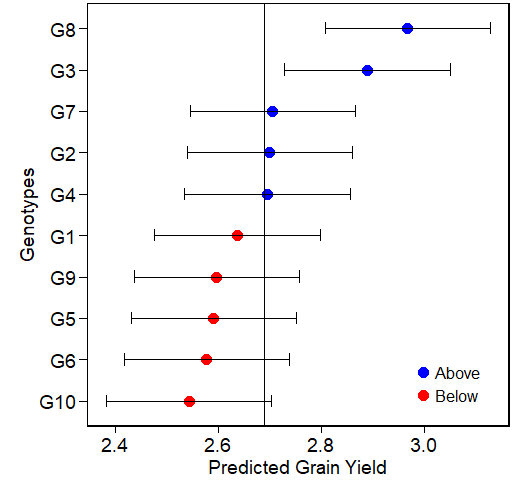

```r
# No file exported
plot.blup(WAASB)
```

This output shows the predicted means for genotypes. **BLUPg** is the genotypic effect $(\hat{g}_{i})$ estimated by $\hat{g}_{i} = h_g^2(\bar{y}_{i.}-\bar{y}_{..})$ where $h_g^2$ is the shrinkage effect for genotype. **Predicted** is the predicted mean estimated by $\hat{g}_{i}+\mu$ where is the grand mean. **LL** and **UL** are the lower and upper limits, respectively, estimated by $(\hat{g}_{i}+\mu)\pm{CI}$. $CI$ is the confidence interval for BLUP prediction assuming a given probability error, where $CI = t\times\sqrt{((1-Ac)\times{GV)}}$ where $t$ is the Student’s *t* value for a two-tailed t test at a given probability error; $Ac$ is the genotypic accuracy and $GV$ is the genotypic variance.

> printing the estimated BLUP for genotypes X environment

```r
options (digits = 4)
print(WAASB$BLUPgge[1:10,])
```

| ENV | GEN | BLUPge | BLUPg | BLUPg+ge | Predicted | LL | UL |
| --- | --- | --- | --- | --- | --- | --- | --- |
| CF2010 | G1 | -0.0659 | -0.0536 | -0.1195 | 2.401 | 2.241 | 2.562 |
| CF2010 | G10 | -0.2594 | -0.1473 | -0.4067 | 2.114 | 1.953 | 2.275 |
| CF2010 | G2 | 0.2415 | 0.0095 | 0.2510 | 2.772 | 2.611 | 2.932 |
| CF2010 | G3 | 0.1092 | 0.1994 | 0.3087 | 2.829 | 2.669 | 2.990 |
| CF2010 | G4 | 0.0410 | 0.0049 | 0.0459 | 2.567 | 2.406 | 2.727 |
| CF2010 | G5 | -0.1508 | -0.0999 | -0.2507 | 2.270 | 2.109 | 2.431 |
| CF2010 | G6 | -0.0696 | -0.1128 | -0.1825 | 2.338 | 2.178 | 2.499 |
| CF2010 | G7 | 0.1543 | 0.0153 | 0.1697 | 2.690 | 2.530 | 2.851 |
| CF2010 | G8 | 0.0655 | 0.2778 | 0.3433 | 2.864 | 2.703 | 3.025 |
| CF2010 | G9 | -0.0658 | -0.0934 | -0.1592 | 2.361 | 2.201 | 2.522 |

This output shows the predicted means for each genotype and environment combination **BLUPg** is the genotypic effect described above. **BLUPge** is the genotypic effect of the *i*th genotype in the *j*th environment $(\hat{g}_{ij})$ estimated by $\hat{g}_{ij} = h_g^2(\bar{y}_{i.}-\bar{y}_{..})+h_{ge}^2(y_{ij}-\bar{y}_{i.}-\bar{y}_{.j}+\bar{y}_{..})$, where $h_{ge}^2$ is the shrinkage effect for genotype-by-environment interaction; **BLUPg+ge** is $BLUP_g+BLUP_{ge}$; **Predicted** is the predicted mean ($\hat{y}_{ij}$) estimated by $\hat{y}_{ij} = \bar{y}_{.j}+BLUP_{g+ge}$.

> printing the eigenvalues

```r
options (digits = 4)

print(WAASB$PCA)
```

| PC | Eigenvalue | Proportion | Accumulated |
| --- | --- | --- | --- |
| 1 | 1.8409 | 32.4894 | 32.49 |
| 2 | 1.5178 | 26.7875 | 59.28 |
| 3 | 0.9574 | 16.8973 | 76.17 |
| 4 | 0.5214 | 9.2020 | 85.38 |
| 5 | 0.3839 | 6.7746 | 92.15 |
| 6 | 0.2218 | 3.9149 | 96.07 |
| 7 | 0.1060 | 1.8712 | 97.94 |
| 8 | 0.0843 | 1.4878 | 99.42 |
| 9 | 0.0326 | 0.5752 | 100.00 |

> Plotting the eigenvalues

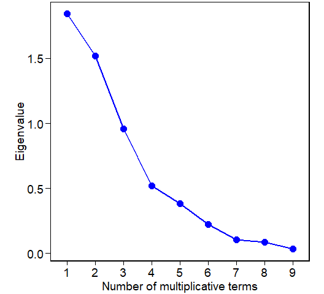

```r
plot.eigen(WAASB, size.lab = 14, size.tex = 14)
```

The above output shows the eigenvalues and the proportion of variance explained by each principal component axis of the BLUP interaction effects matrix.

> printing the phenotypic means for all genotype x environment combinations

```r
options (digits = 4)
print(WAASB$MeansGxE[1:10,])
```

| ENV | GEN | Y | envPC1 | genPC1 | nominal |
| --- | --- | --- | --- | --- | --- |
| CF2010 | G1 | 2.366 | 0.2326 | 0.1097 | 2.649 |
| CF2010 | G10 | 1.974 | 0.2326 | -0.7340 | 2.335 |
| CF2010 | G2 | 2.902 | 0.2326 | 0.0630 | 2.717 |
| CF2010 | G3 | 2.888 | 0.2326 | -0.0830 | 2.922 |
| CF2010 | G4 | 2.589 | 0.2326 | 0.2908 | 2.765 |
| CF2010 | G5 | 2.189 | 0.2326 | 0.0776 | 2.584 |
| CF2010 | G6 | 2.301 | 0.2326 | 0.1195 | 2.577 |
| CF2010 | G7 | 2.774 | 0.2326 | 0.6690 | 2.866 |
| CF2010 | G8 | 2.899 | 0.2326 | -0.0203 | 3.034 |
| CF2010 | G9 | 2.326 | 0.2326 | -0.4923 | 2.459 |

Is the phenotypic mean for each genotype and environment combination ($y_{ij}$), estimated by $y_{ij} = \sum_k{y_{ij}}/B$ with $k = 1,2,...B$.

## 6.2 plotting the scores

### 6.2.1 biplot type 1: PC1 x PC2

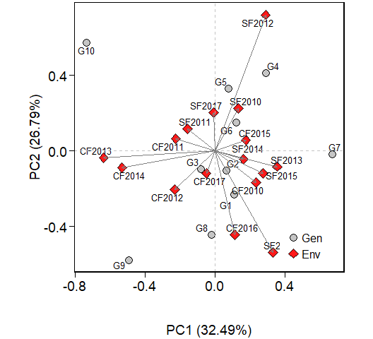

```r
# No file exported
plot.scores(WAASB,
            type = 1)
```

### 6.2.2 biplot type 2: GY x PC1

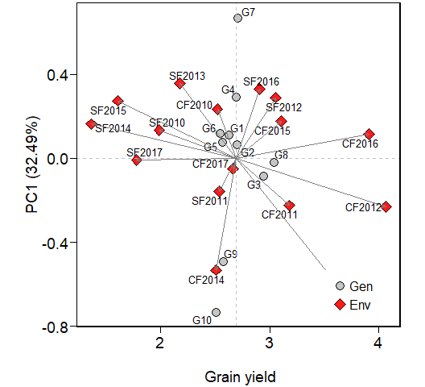

```r
plot.scores(WAASB,
            type = 2)
```

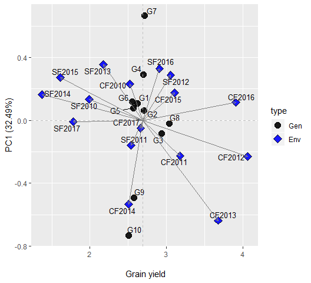

```r
# dafault theme of ggplot2
library(ggplot2)
plot.scores(WAASB,
            type = 2,
            col.gen = "black",
            col.env = "blue",
            theme = theme_gray())
```

### 6.2.3 biplot type 3: GY x WAASB

The quadrants proposed in the following biplot represent the four classifications proposed here regarding the joint interpretation of productivity and stability. The genotypes or environments included in the quadrant I can be considered unstable genotypes or environments with high discrimination ability, however with productivity below the grand mean. In quadrant II are included unstable genotypes, however, with productivity above the grand mean. The environments included in this quadrant deserve special attention since, in addition to providing high magnitudes of the response variable, they present a good discrimination ability. Genotypes within the quadrant III have low productivity, but can be considered stable due to lower values of WAASB. The lower this value, the more stable the genotype can be considered. The environments included in this quadrant can be considered as poorly productive and with low discrimination ability. The genotypes within the quadrant IV the genotypes can be considered an “ideal” genotype due to the high magnitude of the response variable and high stability performance (lower values of WAASB).

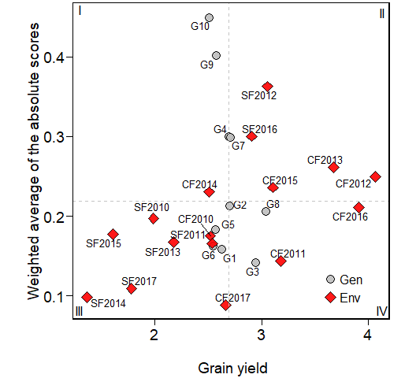

```r
plot.scores(WAASB,
            type = 3)
```

```r
# Save to a *.tiff file with resolution of 600 dpi.
plot.scores(WAASB,
            type = 3,
            export = TRUE,
            file.type = "tiff",
            resolution = 600)
```

### 6.2.4 Nominal yield vs environment IPCA1 scores

Aiming at identifying possible mega-environments as well as visualizing the “which-won-where” pattern of the dataset, a graphic with the nominal yield ($\mathop {\hat y}\nolimits_{ij}^*$) as a function of the environment IPCA1 scores is also produced. In this graphic, each genotype is depicted by a straight line with the equation $\mathop {\hat y}\nolimits_{ij}^* = {\mu _i} + PCA{1_i} \times PCA{1_j}$, where $\mathop {\hat y}\nolimits_{ij}^*$ is the nominal yield for the ith genotype in the jth environment; ${\mu _i}$is the grand mean of the ith genotype; $PC{1_i}$ is the IPCA1 score of the ith genotype and $PCA{1_j}$ is the IPC1 score of the jth environment. The winner genotype in a given environment has the highest nominal yield in that environment. This is the type 4 graphic and can be obtained by the following code.

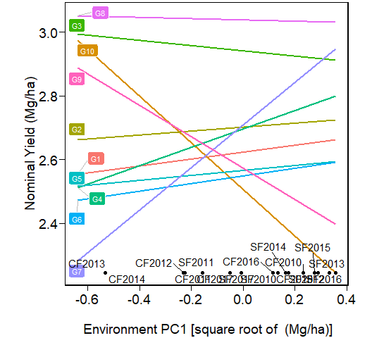

```r
plot.scores(WAASB,
            type = 4)
```

# 7 Estimating the WAASBY index

The function `WAASBratio` considers both stability (weighted average of absolute scores based on SVD of BLUP-interaction effects matrix) and productivity for genotype ranking considering the following model:

$$\begin{aligned}
WAASBY_I =
\frac{\left[W_{GY}\times\left(\left(\frac{GY_i}{GY_{max}}\right)\times 100\right)\right] +
\left[W_{S}\times\left(100-\frac{WAASB_i}{WAASB_{min}}\right)\right]} {W_{GY}+W_{S}}
\end{aligned}$$

where $WAASBY_i$ is the weighted average of absolute scores and productivity of the *i*th genotype; $W_{GY}$ is the weight for grain yield; $GY_i$ is the average grain yield of the *i*th genotype; $GY_{max}$ is the largest average grain yield among the genotypes; $W_S$ is the weight for the stability; $WAASB_i$ is the weighted average of absolute scores of the *i*th genotype; and $WAASB_{min}$ is the smallest value of WAASB.

This function provide the option of attributing weights for stability and productivity in genotype ranking. This is important depending on the goal of a selection strategy. For example, if a goal of a breeding program is to select a genotype whit high yielding (independently on the stability performance), that genotype with the first rank in an WAASB/GY = 0/100 ratio should be selected. The reciprocal is true. Aiming at selecting a high-stable genotype (independently on the productivity), that genotype with the first rank in an WAASB/GY = 100/0 ratio should be selected. By default, the increment on the WAASB/GY ratio is equal to 5. In other words, twenty one different combinations are computed. Each combination, the genotypes are ranked regarding the WAASY value.

```r
WAASBYratio = WAASBYratio(dataset,
                          resp = GY,
                          gen = GEN,
                          env = ENV,
                          rep = BLOCK,
                          increment = 10,
                          saveWAASY = 50)
```

## 7.1 Printing the model outputs

> printing the WAASY values

```r
print(WAASBYratio$WAASY)
```

| Code | PesRes | PesWAAS | WAASY | Mean |
| --- | --- | --- | --- | --- |
| G10 | 50 | 50 | 89.40 | below |
| G9 | 50 | 50 | 90.74 | below |
| G6 | 50 | 50 | 91.35 | below |
| G5 | 50 | 50 | 91.52 | below |
| G1 | 50 | 50 | 92.57 | below |
| G4 | 50 | 50 | 93.21 | below |
| G7 | 50 | 50 | 93.40 | above |
| G2 | 50 | 50 | 93.68 | above |
| G3 | 50 | 50 | 97.88 | above |
| G8 | 50 | 50 | 99.23 | above |

> Printing the genotype ranking for each scenario

```r
print(WAASBYratio$hetcomb)
```

|  | 100/0 | 90/10 | 80/20 | 70/30 | 60/40 | 50/50 | 40/60 | 30/70 | 20/80 | 10/90 | 0/100 |
| --- | --- | --- | --- | --- | --- | --- | --- | --- | --- | --- | --- |
| G1 | 3 | 3 | 4 | 5 | 6 | 6 | 6 | 6 | 6 | 6 | 6 |
| G10 | 10 | 10 | 10 | 10 | 10 | 10 | 10 | 10 | 10 | 10 | 10 |
| G2 | 6 | 4 | 3 | 3 | 3 | 3 | 3 | 3 | 4 | 4 | 4 |
| G3 | 1 | 1 | 2 | 2 | 2 | 2 | 2 | 2 | 2 | 2 | 2 |
| G4 | 7 | 7 | 6 | 6 | 5 | 5 | 5 | 5 | 5 | 5 | 5 |
| G5 | 4 | 6 | 8 | 7 | 7 | 7 | 7 | 7 | 7 | 8 | 8 |
| G6 | 2 | 5 | 7 | 8 | 8 | 8 | 8 | 8 | 9 | 9 | 9 |
| G7 | 8 | 8 | 5 | 4 | 4 | 4 | 4 | 4 | 3 | 3 | 3 |
| G8 | 5 | 2 | 1 | 1 | 1 | 1 | 1 | 1 | 1 | 1 | 1 |
| G9 | 9 | 9 | 9 | 9 | 9 | 9 | 9 | 9 | 8 | 7 | 7 |

> Printing the genotype ranking depending on the number of multiplicative terms used to estimate the WAASB index.

```r
print(WAASBYratio$hetdata)
```

|  | 9PCA | 8PCA | 7PCA | 6PCA | 5PCA | 4PCA | 3PCA | 2PCA | 1PCA |
| --- | --- | --- | --- | --- | --- | --- | --- | --- | --- |
| G1 | 3 | 3 | 2 | 2 | 2 | 2 | 3 | 4 | 5 |
| G10 | 10 | 10 | 10 | 10 | 10 | 10 | 10 | 10 | 10 |
| G2 | 6 | 6 | 6 | 6 | 6 | 6 | 6 | 1 | 2 |
| G3 | 1 | 1 | 1 | 1 | 1 | 1 | 1 | 2 | 4 |
| G4 | 7 | 7 | 7 | 7 | 7 | 7 | 8 | 7 | 7 |
| G5 | 4 | 4 | 4 | 4 | 4 | 4 | 4 | 5 | 3 |
| G6 | 2 | 2 | 3 | 3 | 3 | 3 | 2 | 3 | 6 |
| G7 | 8 | 8 | 8 | 8 | 8 | 8 | 7 | 8 | 9 |
| G8 | 5 | 5 | 5 | 5 | 5 | 5 | 5 | 6 | 1 |
| G9 | 9 | 9 | 9 | 9 | 9 | 9 | 9 | 9 | 8 |

## 7.2 plotting the WAASBY values

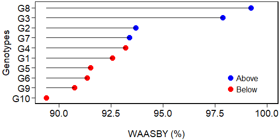

```r
plot.WAASBY(WAASBYratio,
            theme = theme_waasb() +
                    theme(aspect.ratio = NULL,
                          legend.position = c(0.85, 0.2)))
```

## 7.3 Plotting the heat map graphics

The first type of heatmap shows the genotype ranking depending on the number of principal component axis used for estimating the WAASB index. A euclidean distance-based dendrogram is used for grouping the genotype ranking for both genotypes and principal component axis. The second type of heatmap shows the genotype ranking depending on the WAASB/GY ratio. The ranks obtained with a ratio of 100/0 considers exclusively the stability for genotype ranking. On the other hand, a ratio of 0/100 considers exclusively the productivity for genotype ranking. Four clusters are estimated (1) unproductive and unstable genotypes; (2) productive, but unstable genotypes; (3) stable, but unproductive genotypes; and (4), productive and stable genotypes.

### 7.3.1 Ranks of genotypes depending on the number PCAs used to estimate the WAASB

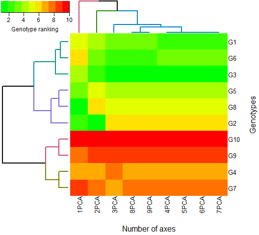

```r
plot.WAASBYratio(WAASBYratio,
                 type = 1)
```

```r
# save to a *.pdf file (default)
plot.WAASBYratio(WAASBYratio,
                 type = 1,
                 export = T)
```

### 7.3.2 Ranks of genotypes depending on the WAASB/GY ratio

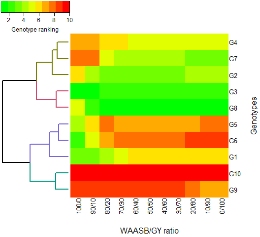

```r
plot.WAASBYratio(WAASBYratio,
                 type = 2)
```

```r
#save to a *tiff file
plot.WAASBYratio(WAASBYratio,
                type = 2,
               export = T,
              file.type = "tiff",
             resolution = 600)
```

# References

Gauch, H.G, and Zobel R.W. 1988. “Predictive and Postdictive Success of Statistical Analyses of Yield Trials.” *Theor. Appl. Genet.* 76 (1): 1–10. doi:10.1007/BF00288824.

Olivoto, T. 2018. “WAASBdata.” *Mendeley Data* V1. doi:10.17632/2sjz32k3s3.1.

Piepho, H.P. 1994. “Best Linear Unbiased Prediction (Blup) for Regional Yield Trials: A Comparison to Additive Main Effects and Multiplicative Interaction (Ammi) Analysis.” *Theor. Appl. Genet.* 89 (5): 647–54. doi:10.1007/BF00222462.